```python
# Mount your drive
from google.colab import drive
drive.mount('/content/drive')
```

```python
# Installing surprise library
!pip install surprise
```

```python
# Basic python libraries
import numpy as np
import pandas as pd

# Python libraries for data visualization
import matplotlib.pyplot as plt
import seaborn as sns

# For implementing matrix factorization based recommendation system
from surprise.prediction_algorithms.matrix_factorization import SVD
from collections import defaultdict

# For implementing cross validation
from surprise.model_selection import KFold

import warnings
warnings.filterwarnings('ignore')
```

```python
from google.colab import files
uploaded = files.upload()
```

Upload widget is only available when the cell has been executed in the current browser session. Please rerun this cell to enable.

```python
# Loading the dataset
Ratings= pd.read_csv("ratings_Electronics.csv")
```

Assign names to the columns

```python
Ratings.columns = ['userId', 'productId', 'rating', 'timestamp']
```

Explore the dataframe

```python
Ratings.head()
```

|  | userId | productId | rating | timestamp |
| --- | --- | --- | --- | --- |
| 0 | A2CX7LUOHB2NDG | 0321732944 | 5.0 | 1341100800 |
| 1 | A2NWSAGRHCP8N5 | 0439886341 | 1.0 | 1367193600 |
| 2 | A2WNBOD3WNDNKT | 0439886341 | 3.0 | 1374451200 |
| 3 | A1GI0U4ZRJA8WN | 0439886341 | 1.0 | 1334707200 |
| 4 | A1QGNMC6O1VW39 | 0511189877 | 5.0 | 1397433600 |

```python
# Checking the info of the data
Ratings.info()
```

```
<class 'pandas.core.frame.DataFrame'>
RangeIndex: 7824481 entries, 0 to 7824480
Data columns (total 4 columns):
 #   Column     Dtype
---  ------     -----
 0   userId     object
 1   productId  object
 2   rating     float64
 3   timestamp  int64
dtypes: float64(1), int64(1), object(2)
memory usage: 238.8+ MB
```

```python
# Rename the columns to the desired names in the specified order
Ratings.columns = ['userId', 'productId', 'rating', 'timestamp']
```

```python
# userId and productID contain combination of letters & digits. So we will convert the column to type 'string'
Ratings['userId']= Ratings['userId'].astype(str)
Ratings['productId']= Ratings['productId'].astype(str)
```

### **Checking the distribution of rating**

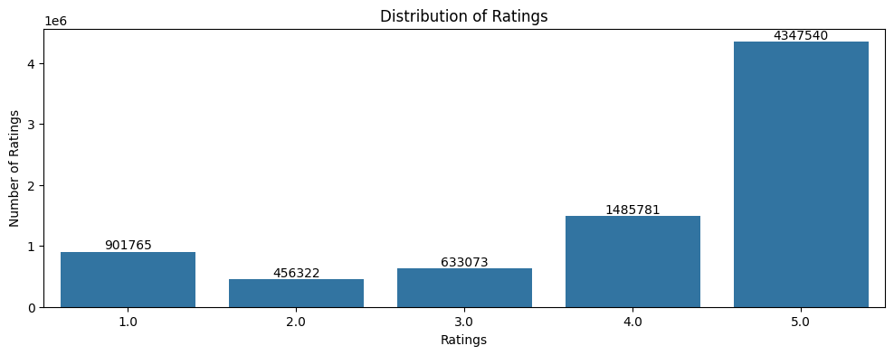

```python
# Distribution of ratings
plt.figure(figsize=(12, 4))
sns.countplot(x="rating", data=Ratings)

# Get the counts of each rating
rating_counts = Ratings['rating'].value_counts().sort_index()

# Add count labels on top of each bar
for i, count in enumerate(rating_counts):
    plt.text(i, count, str(count), ha='center', va='bottom')

plt.tick_params(labelsize=10)
plt.title("Distribution of Ratings", fontsize=12)
plt.xlabel("Ratings", fontsize=10)
plt.ylabel("Number of Ratings", fontsize=10)
plt.show()
```

**Observations** The above bar chart showing the distribution of ratings. The interpretation is thus:

Distribution: 1.0 Rating: 901,765 ratings. 2.0 Rating: 456,322 ratings. 3.0 Rating: 633,073 ratings. 4.0 Rating: 1,485,781 ratings. 5.0 Rating: 4,347,540 ratings. Analysis: The majority of ratings are at the highest level (5.0), indicating a positive skew in the data. Ratings of 4.0 and 5.0 together account for a significant portion of the total ratings. Lower ratings (1.0 to 3.0) are less frequent, with the least number of ratings at 2.0. This distribution suggests that most users gave high ratings, with a notable peak at 5.0.

```python
# Finding the number of unique users
Ratings['userId'].nunique()
```

```
4201696
```

```python
# Finding the number of products
Ratings['productId'].nunique()
```

```
476001
```

**Observations:**

- There are **476001 products** in the dataset.
- As per the number of unique users products, there is a **possibility of 4201696 * 476001 = 2,000,011,497,696 ratings** in the dataset. But **we only have 7824481 ratings**, i.e., not every user has rated every product in the dataset. So, we can build a recommendation system to recommend products to users which they have not interacted with.

```python
Ratings.groupby(['userId', 'productId']).count()
```

| userId | productId | rating | timestamp |
| --- | --- | --- | --- |
| A00000262KYZUE4J55XGL | B003UYU16G | 1 | 1 |
| A000063614T1OE0BUSKUT | B00419ZT3E | 1 | 1 |
|  | B00432ZSHG | 1 | 1 |
| A00009182QVLSWIGHLS1B | B009SXR7WE | 1 | 1 |
| A00009661LC9LQPGKJ24G | B004GWQBWY | 1 | 1 |
| ... | ... | ... | ... |
| AZZZRS1YZ8HVP | B001CJOLBW | 1 | 1 |
|  | B00DR0PDNE | 1 | 1 |
| AZZZSIK7NFFVP | B009FU8BR0 | 1 | 1 |
| AZZZWXXUPZ1F3 | B0016CFZQ0 | 1 | 1 |
| AZZZY1W55XHZR | B001GS8G1U | 1 | 1 |

7824481 rows × 2 columns

```python
Ratings.groupby(['userId', 'productId']).count()['rating'].sum()
```

```
7824481
```

**Observation:**

- The **sum is equal to the total number of observations**, which implies that **there is only one interaction between a product and a user**.

#### Which product has the highest number of reviews / ratings in the dataset?

```python
# Finding the most rated products in the dataset
Ratings['productId'].value_counts()
```

| productId | count |
| --- | --- |
| B0074BW614 | 18244 |
| B00DR0PDNE | 16454 |
| B007WTAJTO | 14172 |
| B0019EHU8G | 12285 |
| B006GWO5WK | 12226 |
| ... | ... |
| B004WL91KI | 1 |
| B004WL9FK4 | 1 |
| B004WL9Q2Q | 1 |
| B004WL9R8O | 1 |
| BT008V9J9U | 1 |

476001 rows × 1 columns

**dtype:** int64

**Observations:**

- The **product with product_id: B0074BW614 has been interacted by most users** (**18244**).
- But still, there is a possibility of 4201696-18244 = 4183452 more interactions as we have 4201696 unique users in our datasets. For those 4183452 remaining users, we can build a recommendation system to predict who is most likely to interact with this product.
- Also, out of these 18244 interactions, we need to consider the distribution of ratings as well to check whether this product is the most liked or most disliked book.

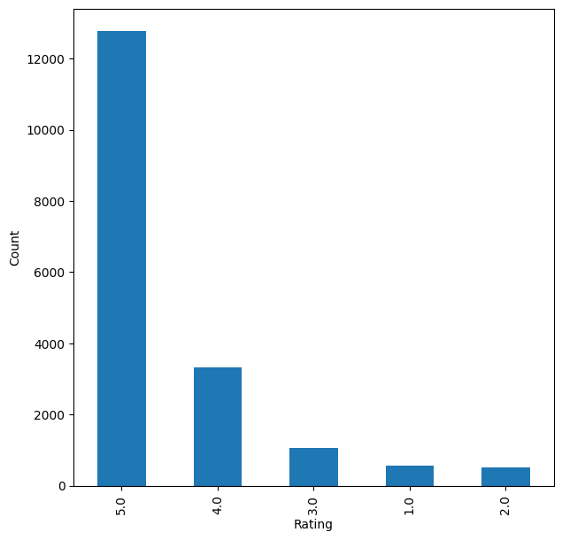

```python
# Plotting distributions of ratings for the most interacted product

plt.figure(figsize=(7,7))

Ratings[Ratings['productId'] == 'B0074BW614']['rating'].value_counts().plot(kind='bar')

plt.xlabel('Rating')

plt.ylabel('Count')
plt.show()
```

```python
Ratings['userId'].value_counts()
```

| userId | count |
| --- | --- |
| A5JLAU2ARJ0BO | 520 |
| ADLVFFE4VBT8 | 501 |
| A3OXHLG6DIBRW8 | 498 |
| A6FIAB28IS79 | 431 |
| A680RUE1FDO8B | 406 |
| ... | ... |
| A1WBP7XSZI6AUL | 1 |
| A2K7UNJHE9ZR0G | 1 |
| A1A6SIW6EWF6FP | 1 |
| A1JRDVWYUF8W0P | 1 |
| A10M2KEFPEQDHN | 1 |

4201696 rows × 1 columns

**dtype:** int64

**Observations:**

- The user with **userID: A5JLAU2ARJ0BO** has interacted with the most number of books, i.e., **520** times.
- But still, there is a possibility of 476001 -520 = 475,481 more interactions as we have 476001 unique products in the dataset.

**Data Preparation**

```python
# Get the column containing the users
users = Ratings.userId
# Create a dictionary from users to find their number of products
rating_count = dict()
for user in users:
    # If we already have the user, just add 1 to their rating count
    if user in rating_count:
        rating_count[user] += 1
    # Otherwise, set their rating count to 1
    else:
        rating_count[user] = 1
```

```python
# We want our users to have at least 50 ratings to be considered
RATINGS_CUTOFF = 50
remove_users = []
for user, num_ratings in rating_count.items():
    if num_ratings < RATINGS_CUTOFF:
        remove_users.append(user)
df = Ratings.loc[~Ratings.userId.isin(remove_users)]
```

```python
df.shape
```

```
(125871, 4)
```

```python
# Get the column containing the products
products = Ratings.productId
# Create a dictionary from products to find their number of users
rating_count = dict()
for product in products:
    # If we already have the product, just add 1 to their rating count
    if product in rating_count:
        rating_count[product] += 1
    # Otherwise, set their rating count to 1
    else:
        rating_count[product] = 1
```

```python
# We want our product to be interacted by at least 30 users to be considered
RATINGS_CUTOFF = 10000
remove_products = []
for product, num_ratings in rating_count.items():
    if num_ratings < RATINGS_CUTOFF:
        remove_products.append(products)
df= Ratings.loc[~Ratings.productId.isin(remove_products)]
```

```python
df.shape
```

```
(7824481, 4)
```

### **Distribution of the user-products interactions in the dataset**

```python
df.nunique()
```

|  | 0 |
| --- | --- |
| userId | 4201696 |
| productId | 476001 |
| rating | 5 |
| timestamp | 5489 |

**dtype:** int64

```python
# Finding user-products interactions distribution
count_interactions = df.groupby('userId').count()['productId']
count_interactions
```

| userId | productId |
| --- | --- |
| A00000262KYZUE4J55XGL | 1 |
| A000063614T1OE0BUSKUT | 2 |
| A00009182QVLSWIGHLS1B | 1 |
| A00009661LC9LQPGKJ24G | 1 |
| A00010809P09NUU6ZP6H | 1 |
| ... | ... |
| AZZZOVIBXHGDR | 3 |
| AZZZRS1YZ8HVP | 2 |
| AZZZSIK7NFFVP | 1 |
| AZZZWXXUPZ1F3 | 1 |
| AZZZY1W55XHZR | 1 |

4201696 rows × 1 columns

**dtype:** int64

[figure not shown]

```python
# Plotting user-product interactions distribution

plt.figure(figsize=(15,7))

sns.histplot(count_interactions)

plt.xlabel('Number of Interactions by Users')

plt.show()
```

## **Model 1: Create Rank-Based Recommendation System**

- Rank-based recommendation systems provide recommendations based on the most popular items. This kind of recommendation system is useful when we have cold start problems.
- To build the rank-based recommendation system, we take average of all the ratings provided to each product and then rank them based on their average rating.

```python
# Calculating average ratings
average_rating = df.groupby('productId')['rating'].mean()

# Calculating the count of ratings
count_rating = df.groupby('productId')['rating'].count()

# Making a dataframe with the count and average of ratings
final_rating = pd.DataFrame({'avg_rating':average_rating, 'rating_count':count_rating})
```

```python
final_rating.head()
```

| productId | avg_rating | rating_count |
| --- | --- | --- |
| 0594451647 | 5.000000 | 1 |
| 0594481813 | 3.000000 | 1 |
| 0970407998 | 2.500000 | 2 |
| 0972683275 | 4.750000 | 4 |
| 1400501466 | 3.333333 | 6 |

```python
final_rating['rating_count'].value_counts()
```

| rating_count | count |
| --- | --- |
| 1 | 179737 |
| 2 | 72180 |
| 3 | 40402 |
| 4 | 25899 |
| 5 | 18607 |
| ... | ... |
| 4567 | 1 |
| 2588 | 1 |
| 887 | 1 |
| 1637 | 1 |
| 1097 | 1 |

1493 rows × 1 columns

**dtype:** int64

Now, let's create a function to find the **top 5 books** for a recommendation based on the average ratings of books. We can also add a **threshold for a minimum number of interactions** for a book to be considered for recommendation.

```python
def top_n_products(data, n, min_interaction=100):

    # Finding products with minimum number of interactions
    recommendations = data[data['rating_count'] > min_interaction]

    # Sorting values w.r.t. average rating
    recommendations = recommendations.sort_values(by='avg_rating', ascending=False)

    return recommendations.index[:n]
```

##### **Recommending top 5 products with 50 minimum interactions based on popularity**

```python
res = list(top_n_products(final_rating, 5, 50))
# Name of the products
list_of_products = []
for i in res:
    list_of_products.append(df[df['productId']== str(i) ])
list_of_products
```

```
[                 userId   productId  rating   timestamp
 2563597   AGX2K0FMS0IVL  B002E6R7NG     5.0  1364947200
 2563598  A3D59IHXIGBCGX  B002E6R7NG     5.0  1359504000
 2563599  A1N3C361B0ZNWE  B002E6R7NG     5.0  1393027200
 2563600   AC0XQ7XB0EQ7F  B002E6R7NG     5.0  1384300800
 2563601  A1IIWDIZ6CC5W5  B002E6R7NG     5.0  1356048000
 2563602  A3CS2UAHDUGU8T  B002E6R7NG     5.0  1345507200
 2563603  A138BEWICVHYM1  B002E6R7NG     5.0  1394755200
 2563604    AMQET1PY0KC9  B002E6R7NG     5.0  1382659200
 2563605  A3A1JKH6FU935A  B002E6R7NG     5.0  1389657600
 2563606  A27RKEYR0NRQ2U  B002E6R7NG     5.0  1391990400
 2563607  A3P5QLJ3AYB0DL  B002E6R7NG     5.0  1390867200
 2563608  A1XEQGYY1IL8CD  B002E6R7NG     5.0  1353369600
 2563609  A1DEEH8UBT87GM  B002E6R7NG     5.0  1360972800
 2563610  A3GB4J9DVXTH1G  B002E6R7NG     5.0  1404259200
```

[output cut: 183 more lines]

Top 5 products to recommend based on 50 interactions are:

1. B002E6R7NG
2. B004I763AW
3. B003J9QQWU
4. B0043ZLFXE
5. B00TMFYBO

##### **Recommending top 5 products with 100 minimum interactions based on popularity**

```python
res = list(top_n_products(final_rating, 5, 100))
# Name of the products
list_of_products = []
for i in res:
    list_of_products.append(df[df['productId']== str(i) ])
list_of_products
```

```
[                 userId   productId  rating   timestamp
 7705972  A1U11IP6K6NHAK  B00GMRCAC6     5.0  1396915200
 7705973   AW6GK3GIWEDZU  B00GMRCAC6     5.0  1390003200
 7705974  A1UE2CSKFE9P49  B00GMRCAC6     5.0  1398384000
 7705975  A390XPHE9J7DBO  B00GMRCAC6     5.0  1401321600
 7705976  A1VRVXIL9WF47J  B00GMRCAC6     5.0  1403481600
 ...                 ...         ...     ...         ...
 7706154  A1XXV4XPKMB4DG  B00GMRCAC6     5.0  1402876800
 7706155   AAOYA0DKWED4W  B00GMRCAC6     5.0  1400630400
 7706156  A3CJNVTBLSE993  B00GMRCAC6     5.0  1400544000
 7706157   A764VQE2KCGCA  B00GMRCAC6     5.0  1395187200
 7706158  A18JF0T0GOCORW  B00GMRCAC6     5.0  1401753600

 [187 rows x 4 columns],
                  userId   productId  rating   timestamp
```

[output cut: 55 more lines]

Top 5 recommendations based on 100 interactions

1. B00GMRCAC6
2. B008I6RVZU
3. B00CG70K78
4. B000053HC5
5. B008VGCT9K

## **Model 2: Collaborative Filtering Based Recommendation System**

Below we are building a similarity-based recommendation system using cosine similarity and using KNN to find similar users who are the nearest neighbor to the given user.

```python
# To compute the accuracy of models
from surprise import accuracy

# Class is used to parse a file containing ratings, data should be in the structure - user ; item ; rating
from surprise.reader import Reader

# Class for loading datasets
from surprise.dataset import Dataset

# For tuning model hyperparameters
from surprise.model_selection import GridSearchCV

# For splitting the rating data in train and test dataset
from surprise.model_selection import train_test_split

# For implementing similarity-based recommendation system
from surprise.prediction_algorithms.knns import KNNBasic
```

```python
def precision_recall_at_k(model, k=10, threshold=7):

    # First map the predictions to each user
    user_est_true = defaultdict(list)

    # Making predictions on the test data
    predictions=model.test(testset)

    for uid, _, true_r, est, _ in predictions:
        user_est_true[uid].append((est, true_r))

    precisions = dict()
    recalls = dict()
    for uid, user_ratings in user_est_true.items():

        # Sort user ratings by estimated value
        user_ratings.sort(key=lambda x: x[0], reverse=True)

        # Number of relevant items
        n_rel = sum((true_r >= threshold) for (_, true_r) in user_ratings)

        # Number of recommended items in top k
        n_rec_k = sum((est >= threshold) for (est, _) in user_ratings[:k])

        # Number of relevant and recommended items in top k
        n_rel_and_rec_k = sum(((true_r >= threshold) and (est >= threshold))
                              for (est, true_r) in user_ratings[:k])

        # Precision@K: Proportion of recommended items that are relevant
        # When n_rec_k is 0, Precision is undefined. We here set Precision to 0 when n_rec_k is 0.

        precisions[uid] = n_rel_and_rec_k / n_rec_k if n_rec_k != 0 else 0

        # Recall@K: Proportion of relevant items that are recommended
        # When n_rel is 0, Recall is undefined. We here set Recall to 0 when n_rel is 0.

        recalls[uid] = n_rel_and_rec_k / n_rel if n_rel != 0 else 0

    # Mean of all the predicted precisions is calculated.
    precision = round((sum(prec for prec in precisions.values()) / len(precisions)),3)
    # Mean of all the predicted recalls is calculated.
    recall = round((sum(rec for rec in recalls.values()) / len(recalls)),3)

    accuracy.rmse(predictions)
    print('Precision: ', precision) # Command to print the overall precision
    print('Recall: ', recall) # Command to print the overall recall
    print('F_1 score: ', round((2*precision*recall)/(precision+recall),3)) # Formula to compute the F-1 score
```

**Let's encode the userId and productId for simplicity, also encoding them will not make any change in the prediction.**

```python
from sklearn.preprocessing import LabelEncoder

# Initialize LabelEncoder for each column
le_user = LabelEncoder()
le_product = LabelEncoder()

# Apply LabelEncoder to 'userId' and 'productId' separately
data = Ratings.copy()
data['userId'] = le_user.fit_transform(df['userId'])
data['productId'] = le_product.fit_transform(df['productId'])

# 'Ratings' column is already numeric, so no encoding is needed
data.head()
```

|  | userId | productId | rating | timestamp |
| --- | --- | --- | --- | --- |
| 0 | 1512496 | 0 | 5.0 | 1341100800 |
| 1 | 1850798 | 1 | 1.0 | 1367193600 |
| 2 | 2118940 | 1 | 3.0 | 1374451200 |
| 3 | 511952 | 1 | 1.0 | 1334707200 |
| 4 | 819547 | 2 | 5.0 | 1397433600 |

```python
# Creating a copy of the above dataset for further use
df_ratings = data.copy()
```

```python
# Calculating average ratings
average_rating = data.groupby('productId')['rating'].mean()

# Calculating the count of ratings
count_rating = data.groupby('productId')['rating'].count()

# Updating the final_rating dataframe with the new encoded book_id count and average of ratings based on the new dataframe
final_rating = pd.DataFrame({'avg_rating':average_rating, 'rating_count':count_rating})
final_rating.head()
```

| productId | avg_rating | rating_count |
| --- | --- | --- |
| 0 | 5.000000 | 1 |
| 1 | 1.666667 | 3 |
| 2 | 4.500000 | 6 |
| 3 | 2.851852 | 27 |
| 4 | 3.000000 | 1 |

**Making the dataset into surprise dataset and splitting it into train and test set**

```python
# Instantiating Reader scale with expected rating scale
reader = Reader(rating_scale=(1, 10))

# Loading the rating dataset
data = Dataset.load_from_df(data[['userId', 'productId', 'rating']], reader)

# Splitting the data into train and test dataset
trainset, testset = train_test_split(data, test_size=0.3, random_state=42)
```

### **User-Based Collaborative Filtering Recommendation System**

### **Implementing the recommendation algorithm based on optimized KNNBasic model**

Below we will be implementing a function where the input parameters are:

- data: a rating dataset
- user_id: user_id against which we want the recommendations
- top_n: the number of items we want to recommend
- algo: the algorithm we want to use to predict the ratings
- The output of the function is a **set of top_n items** recommended for the given user_id based on the given algorithm

```python
import pandas as pd

def get_recommendations(Ratings, userId, top_n, algo):
    # Remove duplicates from the input data
    Ratings= Ratings.drop_duplicates().reset_index(drop=True)

    # Creating an empty list to store the recommended product ids
    recommendations = []

    # Creating a user-item interactions matrix
    user_item_interactions_matrix = Ratings.pivot(index='userId', columns='productId', values='rating')

    # Extracting those product ids which the user_id has not interacted with yet
    non_interacted_items = user_item_interactions_matrix.loc[userId][user_item_interactions_matrix.loc[userId].isnull()].index.tolist()

    # Looping through each of the product id which user_id has not interacted with yet
    for productId in non_interacted_items:
        # Predicting the ratings for those non-interacted product ids by this user
        est = algo.predict(userId, productId).est

        # Appending the predicted ratings
        recommendations.append((productId, est))

    # Sorting the predicted ratings in descending order
    recommendations.sort(key=lambda x: x[1], reverse=True)

    return recommendations[:top_n]  # Returning top n predicted rating items for this user
```

```python
import pandas as pd
from surprise import Dataset, Reader, KNNBasic
from surprise.model_selection import train_test_split
import numpy as np

def get_recommendations(df_ratings, userId, top_n, algo):
    try:
        # Remove duplicates from the input data
        df_ratings = df_ratings.drop_duplicates().reset_index(drop=True)

        # Creating a user-item interactions matrix
        user_item_interactions_matrix = df_ratings.pivot(index='userId', columns='productId', values='rating')

        # Check if the userId exists in the matrix
        if userId not in user_item_interactions_matrix.index:
            print(f"User {userId} not found in the dataset.")
            return []

        # Extracting those product ids which the userId has not interacted with yet
        non_interacted_items = user_item_interactions_matrix.columns[user_item_interactions_matrix.loc[userId].isnull()].tolist()

        recommendations = []
        for productId in non_interacted_items:
            try:
                # Predicting the ratings for those non-interacted product ids by this user
                est = algo.predict(userId, productId).est
                recommendations.append((productId, est))
            except Exception as e:
                print(f"Error predicting for user {userId} and product {productId}: {str(e)}")

        # Sorting the predicted ratings in descending order
        recommendations.sort(key=lambda x: x[1], reverse=True)

        return recommendations[:top_n]
    except Exception as e:
        print(f"Error in get_recommendations: {str(e)}")
        return []



# Check and clean the data
required_columns = ['userId', 'productId', 'rating']
if not all(col in df_ratings.columns for col in required_columns):
    print(f"df_ratings DataFrame must contain columns: {required_columns}")
    print(f"Found columns: {df_ratings.columns.tolist()}")
    exit(1)

df_ratings = df_ratings[required_columns].dropna()
df_ratings['userId'] = df_ratings['userId'].astype(int)
df_ratings['productId'] = df_ratings['productId'].astype(str)
df_ratings['rating'] = df_ratings['rating'].astype(float)

# Remove duplicates
df_ratings = df_ratings.drop_duplicates()

print(f"Using {len(df_ratings)} ratings for recommendations.")

# Prepare the data for Surprise
reader = Reader(rating_scale=(df_ratings['rating'].min(), df_ratings['rating'].max()))
data = Dataset.load_from_df(df_ratings[required_columns], reader)

# Split the data into training and testing sets
trainset, testset = train_test_split(data, test_size=0.25, random_state=42)

# Define and train the similarity algorithm
sim_options = {'name': 'cosine', 'user_based': True}
similarity_algo_optimized = KNNBasic(sim_options=sim_options)
similarity_algo_optimized.fit(trainset)

# Get top 5 recommendations for a specific user
userId = df_ratings['userId'].iloc[0]  # Using the first user in the dataset
recommendations = get_recommendations(df_ratings, userId, 5, similarity_algo_optimized)

if recommendations:
    print(f"\nTop 5 recommended products for user {userId}:")
    for i, (productId, est) in enumerate(recommendations, 1):
        print(f"{i}. Product ID: {productId}, Estimated Rating: {est:.2f}")
else:
    print(f"No recommendations found for user {userId}")
```

```
Using 7824481 ratings for recommendations.
Computing the cosine similarity matrix...
```

[output not shown]

Due to memory related errors above . There is a need to reduce the size of the data to use

```python
import pandas as pd
from surprise import Dataset, Reader, KNNBasic
from surprise.model_selection import train_test_split
import numpy as np

def get_recommendations(df_ratings, userId, top_n, algo):
    try:
        # Check if userId exists in the DataFrame
        if userId not in df_ratings['userId'].values:
            print(f"User {userId} not found in the dataset.")
            return []

        # Creating a user-item interactions matrix for this user only
        user_ratings = df_ratings[df_ratings['userId'] == userId]
        all_products = df_ratings['productId'].unique()
        user_products = user_ratings['productId'].unique()
        non_interacted_items = list(set(all_products) - set(user_products))

        recommendations = []
        for productId in non_interacted_items[:100]:  # Limit to first 100 to save time
            try:
                est = algo.predict(userId, productId).est
                recommendations.append((productId, est))
            except Exception as e:
                print(f"Error predicting for user {userId} and product {productId}: {str(e)}")

        # Sorting the predicted ratings in descending order
        recommendations.sort(key=lambda x: x[1], reverse=True)

        return recommendations[:top_n]
    except Exception as e:
        print(f"Error in get_recommendations: {str(e)}")
        return []

# Print column names to verify
print("Columns in df_ratings:", df_ratings.columns.tolist())

# Check and clean the data
required_columns = ['userId', 'productId', 'rating']
if not all(col in df_ratings.columns for col in required_columns):
    print(f"df_ratings DataFrame must contain columns: {required_columns}")
    print(f"Found columns: {df_ratings.columns.tolist()}")
    exit(1)

df_ratings = df_ratings[required_columns].dropna()
df_ratings['userId'] = df_ratings['userId'].astype(int)
df_ratings['productId'] = df_ratings['productId'].astype(str)
df_ratings['rating'] = df_ratings['rating'].astype(float)

# Remove duplicates
df_ratings = df_ratings.drop_duplicates()

print(f"Using {len(df_ratings)} ratings for recommendations.")

# Prepare the data for Surprise
reader = Reader(rating_scale=(df_ratings['rating'].min(), df_ratings['rating'].max()))
data = Dataset.load_from_df(df_ratings[required_columns], reader)

# Split the data into training and testing sets
trainset, testset = train_test_split(data, test_size=0.25, random_state=42)

# Define and train the similarity algorithm
sim_options = {'name': 'cosine', 'user_based': True}
similarity_algo_optimized = KNNBasic(sim_options=sim_options, k=20)  # Limit to 20 neighbors
similarity_algo_optimized.fit(trainset)

# Get top 5 recommendations for a specific user
userId = df_ratings['userId'].iloc[0]  # Using the first user in the dataset
recommendations = get_recommendations(df_ratings, userId, 5, similarity_algo_optimized)

if recommendations:
    print(f"\nTop 5 recommended products for user {userId}:")
    for i, (productId, est) in enumerate(recommendations, 1):
        print(f"{i}. Product ID: {productId}, Estimated Rating: {est:.2f}")
else:
    print(f"No recommendations found for user {userId}")
```

```
Columns in df_ratings: ['userId', 'productId', 'rating', 'timestamp']
Using 7824481 ratings for recommendations.
Computing the cosine similarity matrix...
```

[output not shown]

Memory issues still persists. I am unable to make a prediction for the user and perform hyperparameter tuning because of this. The code for hyperparameter tuning would have been like below. I would have interpreted the RMSE and comment on precision and recall accordingly

# Setting up parameter grid to tune the hyperparameters

param_grid = {'k': [20, 30, 40], 'min_k': [3, 6, 9], 'sim_options': {'name': ['msd', 'cosine'], 'user_based': [True]} }

# Performing 3-fold cross validation to tune the hyperparameters

gs = GridSearchCV(KNNBasic, param_grid, measures=['rmse', 'mae'], cv=3, n_jobs=-1)

# Fitting the data

gs.fit(data)

# Best RMSE score

print(gs.best_score['rmse'])

# Combination of parameters that gave the best RMSE score

print(gs.best_params['rmse'])

### **Model 3: Item based Collaborative Filtering Recommendation System**

- Foolowing the utilisation of **user-user similarity-based collaborative filtering**. Now, it is important to look into similarity-based collaborative filtering where similarity is calculated **between items**.

```python
# Defining similarity measure
sim_options = {'name': 'cosine',
               'user_based': False}

# Defining nearest neighbour algorithm
algo_knn_item = KNNBasic(sim_options=sim_options,verbose=False)

# Train the algorithm on the train set
algo_knn_item.fit(trainset)

# Let us compute precision@k, recall@k, and f_1 score with k=10
precision_recall_at_k(algo_knn_item)
```

The system crashed while performing above operations as it has used all available RAM. Therefore I am unable to make a prediction with a baseline user, perform tuning of hyperparameters and come up with a final model via grid search cross validation. I would have used below code for hyper parameter tuning :# Setting up parameter grid to tune the hyperparameters. I would have commented on RMSE, recall and precision . Given the above limitations , I am unable to make predictions for top 5 items. param_grid = {'k': [10,20,30], 'min_k': [3,6,9], 'sim_options': {'name': ['msd', 'cosine'], 'user_based': [False]} }

# Performing 3-fold cross validation to tune the hyperparameters

grid_obj = GridSearchCV(KNNBasic, param_grid, measures=['rmse', 'mae'], cv=3)

# Fitting the data

grid_obj.fit(data)

# Best RMSE score

print(grid_obj.best_score['rmse'])

# Combination of parameters that gave the best RMSE score

print(grid_obj.best_params['rmse'])

Model 4:**Matrix** factorisation methods using SVD

```python
# Using SVD matrix factorization
svd = SVD(random_state=1)

# Training the algorithm on the train set
svd.fit(trainset)

# Let us compute precision@k and recall@k with k=10
precision_recall_at_k(svd)
```

```
RMSE: 1.2967
Precision:  0.0
Recall:  0.0
```

[output not shown]

Below code would have been used for the hyperparameters tuning:

# Set the parameter space to tune

param_grid = {'n_epochs': [10, 20, 30], 'lr_all': [0.001, 0.005, 0.01], 'reg_all': [0.2, 0.4, 0.6]}

# Performing 3-fold gridsearch cross validation

gs_ = GridSearchCV(SVD, param_grid, measures=['rmse'], cv=3, n_jobs=-1)

# Fitting data

gs_.fit(data)

# Best RMSE score

print(gs_.best_score['rmse'])

# Combination of parameters that gave the best RMSE score

print(gs_.best_params['rmse'])

The final model by using optimal values via grid-search validation would have been : # Building the optimized SVD model svd_optimized = SVD(n_epochs=30, lr_all=0.005, reg_all=0.2, random_state=1)

# Training the algorithm on the train set

svd_optimized=svd_optimized.fit(trainset)

# Let us compute precision@k and recall@k with k=10

precision_recall_at_k(svd_optimized)

**Conclusion**